# Pstat_131_Final Project_0611

name

2022/6/11

## Introduction

League of Legends (LoL) is an immensely popular multiplayer online battle arena game, with over 100 million monthly active users worldwide.10 players are divided into 2 teams (blue or red) in the main LoL game (there are 3 modes). The objective for each team is to destroy the opposing teams “Nexus”. Think of the Nexus as the main building in a base camp. Destroy the enemy Nexus and your team wins the game.

This dataset contains the first 10min stats of approx 10k ranked games (SOLO QUEUE) from a high ELO (DIAMOND I to MASTER). Players have roughly the same level. Each game is unique. The gameId can be used to fetch more attributes from the Riot API.There are 19 features per team (38 in total) collected after 10min in-game. This includes kills, deaths, gold, experience, level and so on.

I thought it would be fun to explore this data set and see what blue team and red team attributes are associated with a blue team winning.By analyzing some characteristics of the two teams, we will use common machine learning algorithms such as boosted tree,svm,random forest,logistic regression to predict whether the blue team will win the game.

## Loading Data and Packages

The data for this project comes from the kaggle competition platform see https://www.kaggle.com/datasets/bobbyscience/league-of-legends-diamond-ranked-games-10-min. It has a total of 9879 pieces of data. There are 1 response variable and 38 predictor variables. And 36 of them are numeric and 2 of them are binary. The column blueWins is the target value (the value we are trying to predict). A value of 1 means the blue team has won,0 otherwise.

Glossary of independent variables: **Warding totem:**  
An item that a player can put on the map to reveal the nearby area. Very useful for map/objectives control. Minions: NPC that belong to both teams. They give gold when killed by players. **Jungle minions:**  
NPC that belong to NO TEAM. They give gold and buffs when killed by players. **Elite monsters:**  
Monsters with high hp/damage that give a massive bonus (gold/XP/stats) when killed by a team. **Dragons:**  
Elite monster which gives team bonus when killed. The 4th dragon killed by a team gives a massive stats bonus. The 5th dragon (Elder Dragon) offers a huge advantage to the team. **Herald:**  
Elite monster which gives stats bonus when killed by the player. It helps to push a lane and destroys structures. **Towers:**  
Structures you have to destroy to reach the enemy Nexus. They give gold. **Level:**  
Champion level. Start at 1. Max is 18.

```r
library(tidyverse)
library(tidymodels)
library(corrplot)
library(caret)
library(janitor)
library(skimr)
library(patchwork)
library(lubridate)
library(ranger)
library(rlang)
library(ggplot2)
library(corrr)
library(klaR)
library(MASS)
library(discrim)
tidymodels_prefer()
library(installr)
setwd('C:/Users/DELL/Desktop')
high <- read_csv("high.csv")
#View(high)
```

## Data Cleaning

1. checking missing values

We confirmed that none of the variables have missing values.

```r
head(high)
dim(high) #9879   40
apply(is.na(high), 2, sum)  #no missing
```

2. remove unimportant variables

One of the variables is the “gameID”. Since the “gameID” is just a kind of identity and it won’t influence the result of each rank game, we excluded the “gameID” column.

```r
game<-high %>%
  select(-gameId)
```

For the variables end with “PerMin” come from total variables like blueGoldPerMin, it is from the blueTotalGold. At the same time, variable blueKills is equal to the redDeaths. The variables “redGoldDiff” and “redExperienceDiff” come from blueTotalGold minus blueGoldDiff, blueTotalExperience minus blueExperienceDiff. Since “FirstBlood” variable is a binary variable, it will be done by red team or blue team, we only keep one.

We exclude the following variables: blueCSPerMin, redCSPerMin, blueGoldPerMin, redGoldPerMin, redDeaths, redFirstBlood, blueDeaths, redGoldDiff, redExperienceDiff.

```r
game0 = game %>%
  select(-blueCSPerMin, -redCSPerMin, -blueGoldPerMin, -redGoldPerMin, -redDeaths, -redFirstBlood,
         -blueDeaths, -redGoldDiff, -redExperienceDiff)
```

## Data Split

The dataset contains a total of 9879 samples,of which 80% of the data is used as training data about 7903 and 20% of the data is used as test data about 1976.  
Stratified sampling was used based on blueWins(response variable).

```r
set.seed(123)
game_split <-game0 %>%
  initial_split(game0,prop = 0.8, strata = "blueWins")
game_train <- training(game_split)
game_test <- testing(game_split)
dim(game_train) # 7903   39
dim(game_test)  # 1976   39
```

## Exploratory Data Analysis

In order to ensure that we avoid knowing anything about the test set before testing, all our exploratory data analysis is only for the training data set.

### Distribution of Game Results

We first observe the distribution of the game results (response variable), a value of 1 means the blue team wins, and a value of 0 means the blue team loses. We find that the overall probability of winning the two teams is not much different, which proves that the game is fair, the strength of the team is also almost on the same level.

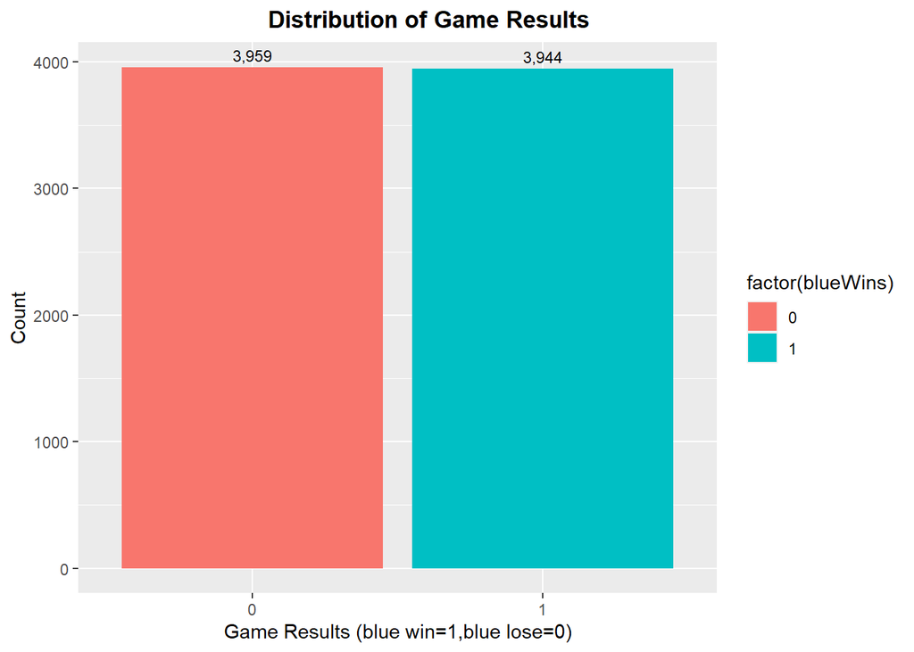

```r
theme <- theme(plot.title = element_text(hjust = 0.6, face = "bold"))

game_train%>%
  ggplot(aes(x = factor(blueWins),
             y = stat(count), fill = factor(blueWins),
             label = scales::comma(stat(count)))) +
  geom_bar(position = "dodge") +
  geom_text(stat = 'count',
            position = position_dodge(.9),
            vjust = -0.5,
            size = 3) +
  labs(x = 'Game Results (blue win=1,blue lose=0)', y = 'Count') +
  ggtitle("Distribution of Game Results") +
  theme
```

### Correlations matrix

In order to explore the correlation between variables, we show the correlation coefficient matrix between the variables, the results show that the correlation between the dependent variable and the response variable is obvious, and there is a clear correlation between the dependent variables.

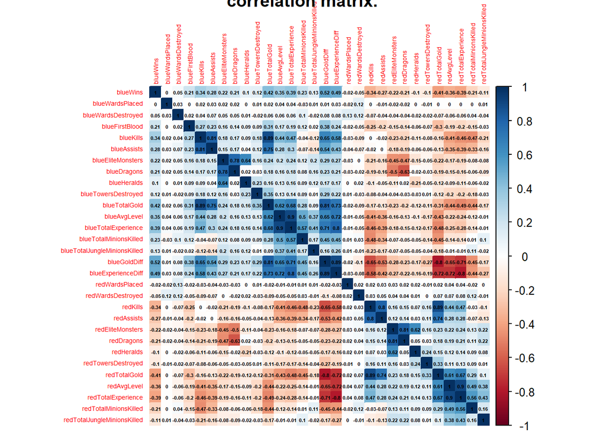

```r
correlations <- cor(game_train,method="pearson") %>%
  corrplot(method = "color",type = "full", addCoef.col = "black"
           , tl.cex = 0.45,number.cex = 0.35,title ='correlation matrix.')
```

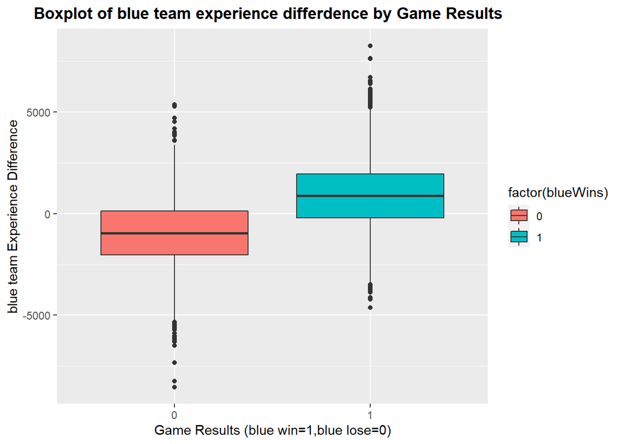

```r
game_train %>%
  ggplot(aes(x = factor(blueWins), y = blueExperienceDiff,fill=factor(blueWins))) +
  geom_boxplot() +
  labs(x = 'Game Results (blue win=1,blue lose=0)', y = 'blue team Experience Difference') +
  ggtitle("Boxplot of blue team experience differdence by Game Results") +
  theme
```

### Boxplot of blue team average level differdence by Game Results

From the correlation coefficient matrix, it can be seen that whether the blue team wins the game has a significant relationship with the average level of the two teams, so we draw the distribution of the average level difference(blue average level-red average level), and the boxplot shows that the on the whole blue team wins When his average level is higher than that of the red team, that is, the average level difference of the two teams is positive, on the contrary, if the blue team lose, the average level difference of the two teams is negative.

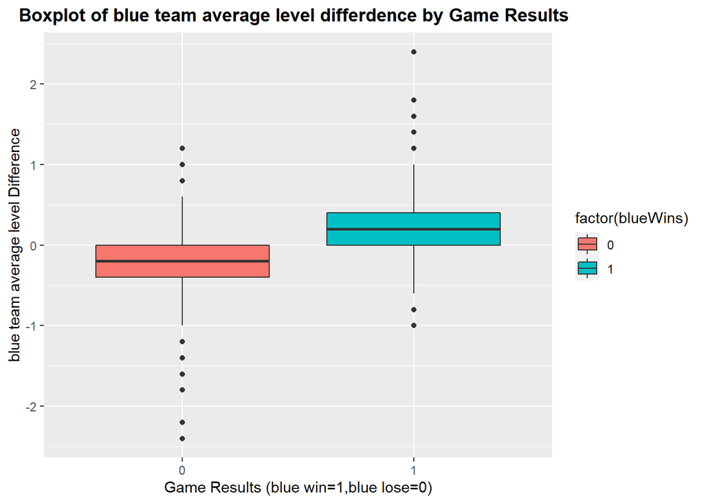

```r
game_train %>%
  ggplot(aes(x = factor(blueWins), y = blueAvgLevel-redAvgLevel,fill=factor(blueWins))) +
  geom_boxplot() +
  labs(x = 'Game Results (blue win=1,blue lose=0)', y = 'blue team average level Difference') +
  ggtitle("Boxplot of blue team average level differdence by Game Results") +
  theme
```

### Distribution of Game results by blue First Blood(1=Yes 0=NO)

From the correlation coefficient graph, we also found that whether the blue team won or not had a positive correlation with whether the blue team did the first kill. We plotted the distribution of the game results in the two cases that the blue team did the first kill and the blue team didn’t the first kill. The results show that when the blue team did the first kill, there is indeed a greater probability of winning the game.

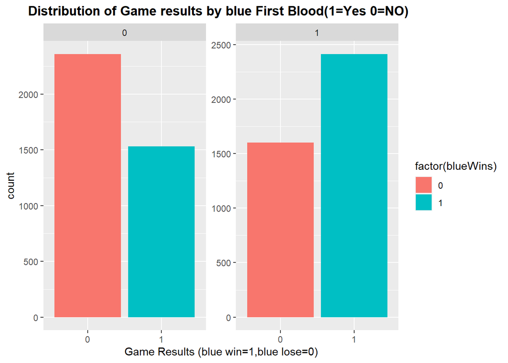

```r
game_train %>%
  ggplot(aes(x = factor(blueWins),
             y = stat(count), fill = factor(blueWins))) +
  geom_bar( ) +
  facet_wrap(~blueFirstBlood, scales = "free_y") +
  labs(x = 'Game Results (blue win=1,blue lose=0)',
    title = "Distribution of Game results by blue First Blood(1=Yes 0=NO)"
  )+
  theme
```

## Model Building

### Data prepare

(1)Convert the response variable to a factor variable and assign a value,while standardizing each independent variable.  
(2)In order to make the training data and test data completely independent and do not affect each other,we preprocess them separately

```r
train <- game_train %>%
  mutate(blueWins=factor(blueWins))

levels(train$blueWins)<-c("lose", "win")

train[,-1] <- scale(train[,-1])

test <- game_test %>%
  mutate(blueWins=factor(blueWins))

levels(test$blueWins)<-c("lose", "win")

test[,-1] <- scale(test[,-1])
```

### Model select

I decided to run cross fold validation on the following four models.  
1.Boosted Tree Model  
2.SVM model  
3.Random Forest model  
4.Logistic regression model

#### Building the Recipe and Tweaking The Data

In order to avoid the computational complexity of the computer, we set up a three-fold cross-validation, repeated three times.

```r
train_folds <- vfold_cv(train, v = 3,repeats = 3)
recipe<-recipe(blueWins ~. , data = train)
recipe
```

#### Boosted Tree Model

I tuned min_n and mtry, set mode to “classification” (because my outcome is a factor variable), and used the xgboost engine.

```r
bt_model <- boost_tree(mode = "classification",
                       min_n = tune(),
                       mtry = tune()
) %>%
  set_engine("xgboost")%>%
  translate()

bt_workflow <- workflow() %>%
  add_model(bt_model) %>%
  add_recipe(recipe)

bt_params <- extract_parameter_set_dials(bt_model) %>%
  update(mtry = mtry(range= c(2, 40)),
         min_n = min_n(range= c(2, 10))
  )

# define grid
bt_grid <- grid_regular(bt_params, levels = 8)
```

Then, I executed my model by tuning and fitting and save the results. This process took 10 minutes.

```r
set.seed(123)
bt_res <- bt_workflow %>%
  tune_grid(resamples = train_folds,
            grid = bt_grid)
#save(bt_res, bt_workflow, file = "D:/bt_res3.rda")
```

Taking a quick peak at the autoplot() function and show_best() based on roc_auc metric.We found that when mtry=2,min_n=7, its mean auc value is close to 80.3%

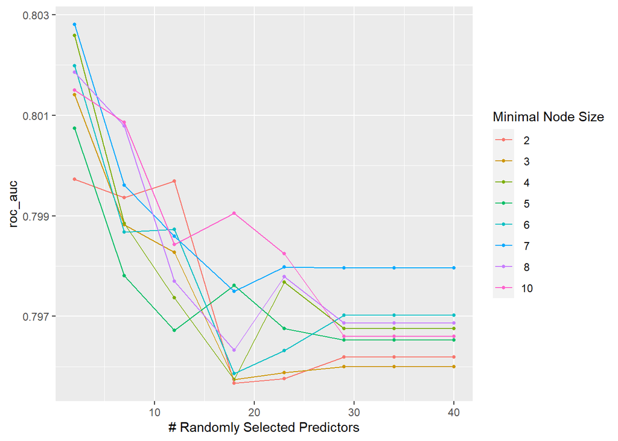

```r
set.seed(123)
load("D:/bt_res3.rda")
autoplot(bt_res, metric = "roc_auc")
```

```r
show_best(bt_res, metric = "roc_auc") %>% select(-.estimator, -.config) #2 7  auc=80.3%
```

```
## # A tibble: 5 x 6
##    mtry min_n .metric  mean     n std_err
##   <int> <int> <chr>   <dbl> <int>   <dbl>
## 1     2     7 roc_auc 0.803     9 0.00224
## 2     2     4 roc_auc 0.803     9 0.00213
## 3     2     6 roc_auc 0.802     9 0.00226
## 4     2     8 roc_auc 0.802     9 0.00258
## 5     2    10 roc_auc 0.802     9 0.00216
```

#### SVM Model

I set mode to “classification” (because my outcome is a factor variable) and tuned cost, and used the kernlab engine.

```r
svm_model <- svm_rbf( cost  = tune())%>%
  set_engine("kernlab")%>%
  set_mode('classification')%>%
  translate()

svm_workflow <- workflow() %>%
  add_model(svm_model) %>%
  add_recipe(recipe)

svm_grid <- tibble(cost = 10^seq(-2, 0, length.out = 20))
```

Then, I executed my model by tuning and fitting and save the results. This process took 20 minutes.

```r
set.seed(123)
svm_res <- svm_workflow %>%
  tune_grid(resamples =train_folds,
            grid = svm_grid)
#save(svm_res, svm_workflow, file = "D:/svm_res3.rda")
```

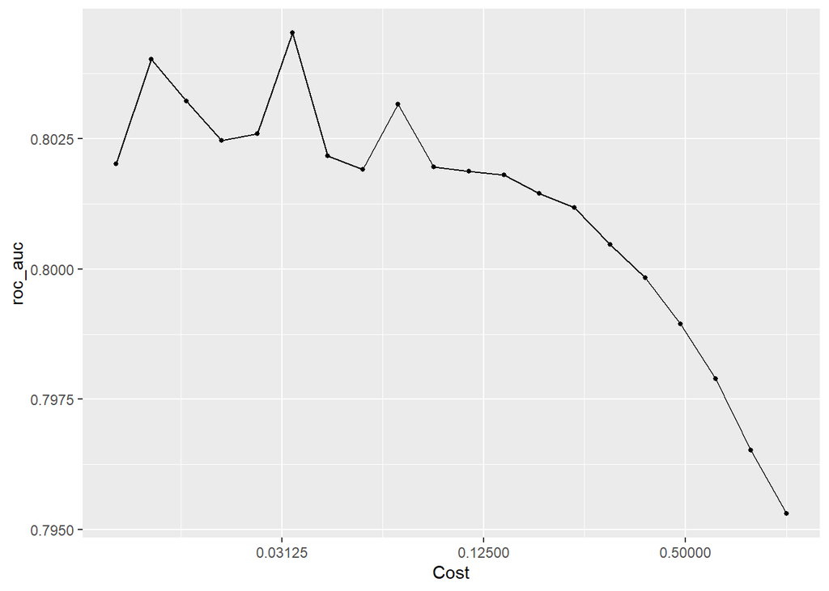

```r
set.seed(123)
load("D:/svm_res3.rda")
autoplot(svm_res, metric = "roc_auc")
```

```r
show_best(svm_res, metric = "roc_auc") %>% select(-.estimator, -.config) #cost=0.0336 auc=80.5%
```

[output not shown]

#### Random Forest Model

I tuned min_n, set mode to “classification” (because my outcome is a factor variable), and used the ranger engine.

```r
rf_model <- rand_forest(mode = "classification",
                        min_n = tune()
) %>%
  set_engine("ranger")

rf_workflow <- workflow() %>%
  add_model(rf_model) %>%
  add_recipe(recipe)

# to reduce computation,so only tune min_n
rf_grid <- tibble(min_n = seq(2, 10) )
```

Then, I executed my model by tuning and fitting and save the results. This process took 15 minutes.

```r
set.seed(123)
rf_res <- rf_workflow %>%
  tune_grid(resamples = train_folds,
            grid = rf_grid
  )
#save(rf_res, rf_workflow, file = "D:/rf_res3.rda")
```

Taking a quick peak at the autoplot() function and show_best() based on roc_auc metric. When min_n is 10,the mean auc value is close to 80.3%,worse than svm model.

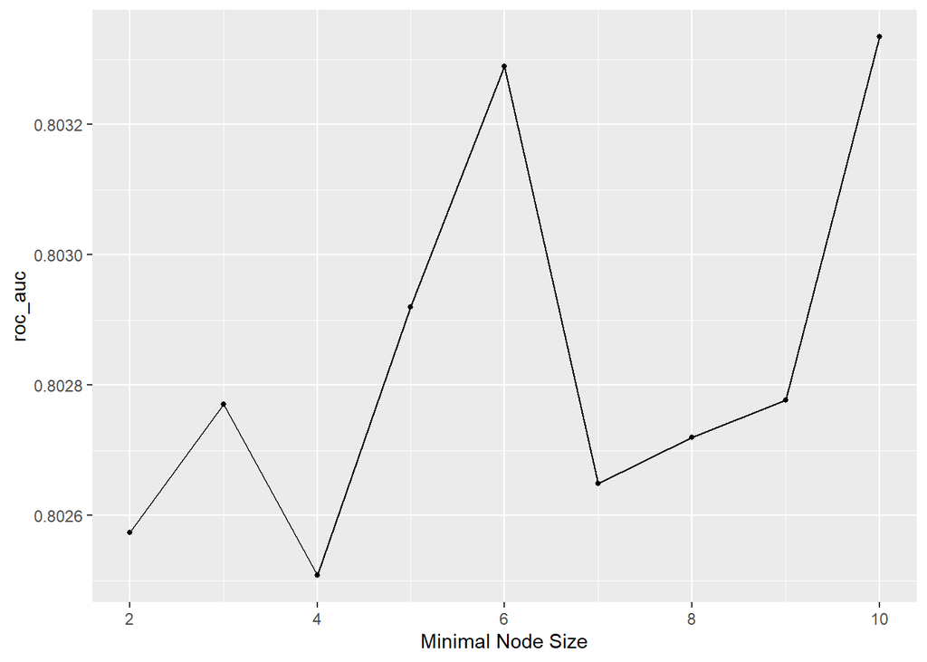

```r
set.seed(123)
load("D:/rf_res3.rda")
autoplot(rf_res, metric = "roc_auc")  ##node=10 most
```

```r
show_best(rf_res, metric = "roc_auc") %>% select(-.estimator, -.config) #mean=80.3%
```

```
## # A tibble: 5 x 5
##   min_n .metric  mean     n std_err
##   <int> <chr>   <dbl> <int>   <dbl>
## 1    10 roc_auc 0.803     9 0.00228
## 2     6 roc_auc 0.803     9 0.00244
## 3     5 roc_auc 0.803     9 0.00235
## 4     9 roc_auc 0.803     9 0.00242
## 5     3 roc_auc 0.803     9 0.00242
```

#### Logistic Regression Model

I tuned penalty, set mode to “classification” (because my outcome is a factor variable), and used the LiblineaR engine. I stored this model and my recipe in a workflow and set up the tuning grid.

```r
log_model <- logistic_reg(penalty = tune(), mixture = 1) %>%
  set_engine("LiblineaR")%>%
  set_mode('classification')

log_workflow <- workflow() %>%
  add_model(log_model) %>%
  add_recipe(recipe)

log_grid <- tibble(penalty = 10^seq(-3, -1, length.out = 20))
```

Then, I executed my model by tuning and fitting and save the results. This process took 2 minutes, it is quickly.

```r
log_res <- log_workflow %>%
  tune_grid(resamples = train_folds,
            grid = log_grid,
            control = control_grid(save_pred = TRUE),
            metrics = metric_set(roc_auc))

#save(log_res, log_workflow, file = "D:/log_res3.rda")
```

Taking a quick peak at the autoplot() function and show_best() based on roc_auc metric.We found that When penalty is 0.00695, auc has a maximum value, its mean auc value is close to 81.1%, better than all above models.

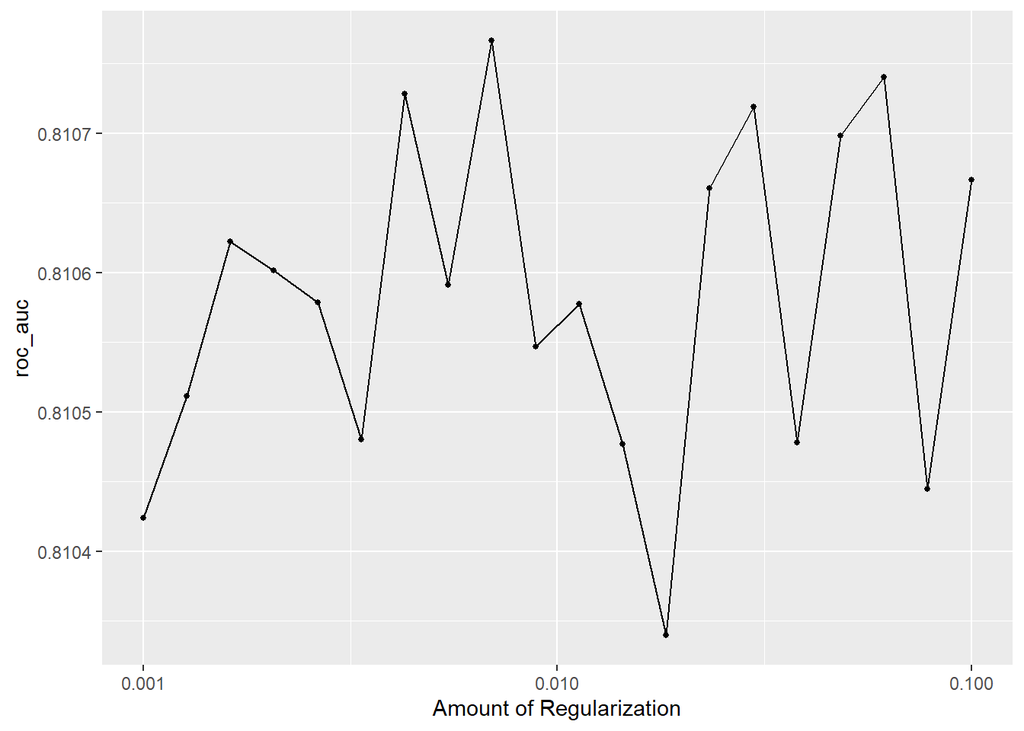

```r
load("D:/log_res3.rda")
autoplot(log_res, metric = "roc_auc")  ##0.009 best
```

```r
show_best(log_res, metric = "roc_auc") %>% dplyr::select(-.estimator, -.config) #81.1% penalty=0.00695
```

```
## # A tibble: 5 x 5
##   penalty .metric  mean     n std_err
##     <dbl> <chr>   <dbl> <int>   <dbl>
## 1 0.00695 roc_auc 0.811     9 0.00195
## 2 0.0616  roc_auc 0.811     9 0.00192
## 3 0.00428 roc_auc 0.811     9 0.00194
## 4 0.0298  roc_auc 0.811     9 0.00191
## 5 0.0483  roc_auc 0.811     9 0.00188
```

### Final Model Building

Let’s continue with the logistic regression model being the model that performed best,it’s mean auc value is highest,closing to 81.1% .

We’ll create a workflow that has tuned in the name, so we can identify it. We’ll finalize the workflow by taking the parameters from the best model (the logistic regression model) using the select_best() function.

```r
set.seed(123)
log_workflow_tuned <- log_workflow %>%
  finalize_workflow(select_best(log_res, metric = "roc_auc"))
log_final <- fit(log_workflow_tuned, train)
```

### Analysis of The Test Set

Lets fit the final logistic model to the testing data set and plot confusion matrix and roc plot.Through the confusion matrix and roc plot, we found that the model can effectively predict whether the blue team wins the game competition, and most of the game results can be correctly predicted.

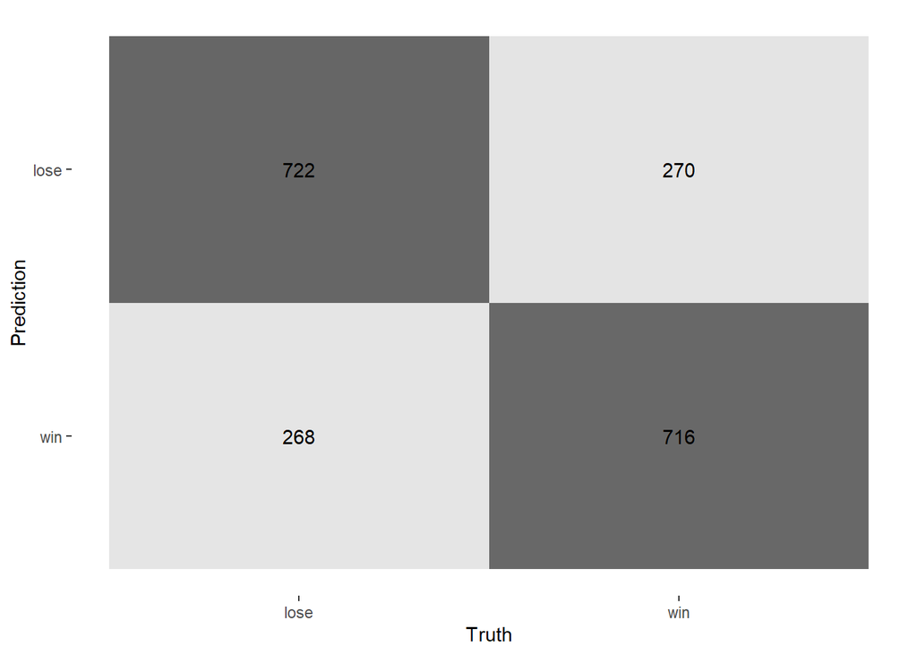

```r
#heatmap
augment(log_final, new_data = test) %>%
  conf_mat(truth = blueWins, estimate = .pred_class) %>%
  autoplot(type = "heatmap")
```

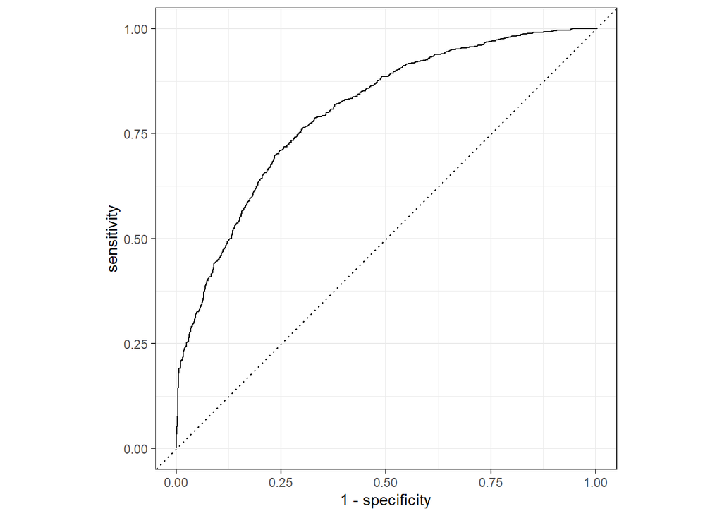

```r
#roc plot
augment(log_final, new_data = test)%>%
  roc_curve(blueWins, .pred_lose) %>%
  autoplot()
```

```r
#calculate accuracy
log_acc <- augment(log_final, new_data = test) %>%
  accuracy(truth = blueWins, estimate = .pred_class)
log_acc # 0.732

#calculate auc
log_auc <- augment(log_final, new_data = test) %>%
  roc_auc(blueWins, .pred_lose)
log_auc # 0.803
```